# Computational Statistics - Lab 02

Annalena Erhard (anner218) and Maximilian Pfundstein (maxpf364)

2019-02-05

# Question 1: Optimizing a Model Param

The file `mortality_rate.csv` contains information about mortality rates of the fruit flies during a certain period.

**Task:** Import this file to R and add one more variable `LMR` to the data which is the natural logarithm of Rate. Afterwards, divide the data into training and test sets.

| Day | Rate | LMR |
| --- | --- | --- |
| 1 | 0.0014 | -6.571283 |
| 2 | 0.0040 | -5.521461 |
| 3 | 0.0051 | -5.278515 |
| 4 | 0.0064 | -5.051457 |
| 5 | 0.0075 | -4.892852 |
| 6 | 0.0098 | -4.625373 |

**Task:** Write your own function `myMSE()` that for given parameters $\lambda$ and list `pars` containing vectors `X`, `Y`, `Xtest`, `Ytest` fits a LOESS model with response `Y` and predictor `X` using `loess()` function with penalty $\lambda$ (parameter `enp.target` in `loess()`) and then predicts the model for `Xtest`. The function should compute the predictive MSE, print it and return as a result. The predictive MSE is the mean square error of the prediction on the testing data. It is defined by the following Equation (for you to implement):

$$\text{predictive MSE}=\frac{1}{\text{length(test)}} \sum_{\text{ith element in test set}}(Y_{test}[i] - fY_{pred}(X[i]))^2$$

where `fYpred(X[i])` is the predicted value of `Y` if `X` is `X[i]`. Read on R’s functions for prediction so that you do not have to implement it yourself.

```r
# Implementation of myMSE -------------------
myMSE = function(lambda, pars) {
  model = loess(Y ~ X, data=pars, enp.target = lambda)
  prediction = predict(model, newdata = pars$Xtest)
  mse = sum((prediction - pars$Ytest)^2)/length(pars$Ytest)
  #print(".")
  return(mse)
}
```

**Task:** Use a simple approach: use function `myMSE()`, training and test sets with response LMR and predictor Day and the following $\lambda$ values to estimate the predictive MSE values: $\lambda = 0.1, 0.2,...40$.

```r
# parameters for the myMSE function ----------------------
pars = list(X = train$Day, Y = train$LMR, Xtest = test$Day, Ytest = test$LMR)
lambdas = seq(from = 0.1, to = 40, by = 0.1)

# applying the myMSE function to all lambdas ------------
mses = sapply(X = lambdas, FUN = myMSE, pars = pars)
```

**Task:** Create a plot of the MSE values versus $\lambda$ and comment on which $\lambda$ value is optimal. How many evaluations of `myMSE()` were required (read `?optimize`) to find this value?

**Answer:** From looking at the plot, it seems like the optimal $\lambda$ is between 10 and 30.

```
## [1] 11.7
```

is best $\lambda$ (for the given input sequence). This minimum can also be seen at the blue point in the plot below. The function was called

```
## [1] 400
```

times.

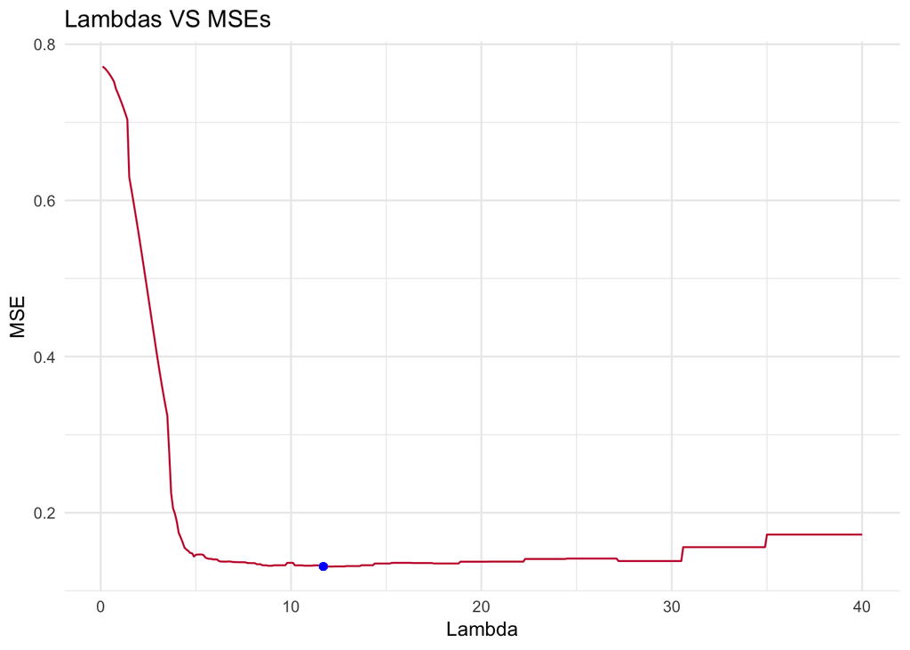

**Task:** Use `optimize()` function for the same purpose, specify range for search `[0.1, 40.0]` and the accuracy `0.01`. Have the function managed to find the optimal MSE value? How many `myMSE()` function evaluations were required? Compare to step 4.

**Answer:** The call for the build in `optimize()` function looks like this:

```r
o = optimize(myMSE, tol = 0.01, interval = c(0.1, 40), pars = pars)
```

This means the minimum could be found at a $\lambda$ of

```
## [1] 10.69361
```

and an MSE of

```
## [1] 0.1321441
```

The function `myMSE()` was called 18 times. We counted the printed dots, we were too lazy to build a wrapper with a counter :).

**Task:** Use `optim()` function and BFGS method with starting point $\lambda = 35$ to find the optimal $\lambda$ value. How many `myMSE()` function evaluations were required (read ?optim)? Compare the results you obtained with the results from step 5 and make conclusions.

```r
optim(35, myMSE, method = "BFGS", pars = pars, control = list(fnscale = 1))
```

```
## $par
## [1] 35
##
## $value
## [1] 0.1719996
##
## $counts
## function gradient
##        1        1
##
## $convergence
## [1] 0
##
## $message
## NULL
```

**Information:** The function `optimize()` searches the whole interval using the golden selection search (description on the course slides), so it is looking for a local minima in the given interval. It uses a constant reduction factor $\alpha$. For this to work the function has to be unimodal, which means that is only has one maxima/minima (in the given interval). So it’s pretty basic and, depending on $\alpha$, we need more or less iterations.

Newtons Method (Nelder-Mead) is memory heavy but therefore converges quickly. It computes an approximation for the Hessian and calculates the quasi–Newton condition or secant condition:

$$B_{k+1}(\vec x_{k+1}- \vec x_k) = \nabla f(\vec x_{k+1}) - \nabla f(\vec x_k)$$

We want the current and the next itertion to be as close as possible. The computations for this can be found on the slides and won’t be mentioned here. One last word about the BGFS (Broyden–Fletcher–Goldfarb–Shanno), which was used here. It needs in general more iterations than Newton, but each iteration is faster to compute, so it’s actually better for large scale problems. The gradient in this case is calculated like this:

$$\nabla f(\vec x) = A\vec x-\vec b = r(\vec x)$$

The gradient is therefore used to calculate an improved lambda value. Since this is `0` at the initial lambda value, the algorithm converges. In contrast to the optimize function, the minimum could not be found here. It is possible, however, that `optim()` works much more efficiently if no `0` gradients occur.